# Two attributes of numerical meaning

Oliver Lindemann

```r
library(tidyverse)
library(lme4)
```

# Description

The study aims to examine the interactions of space- and size-congruity effects while number processing.

The numbers 1 to 9 ($N$) were presented in different six font sizes ($V_\text{size}=[-3, -2, -1, 1, 2, 3]$) and at six different stimulus locations (three left and three right from screen center, $V_\text{space}=[-3, -2, -1, 1, 2, 3]$). For each trial, a size and space-congruity parameter, $C$, could be calculated that varies between $-1$ and $+1$ (see formula below).

The mixed effect model of the reaction times aims to consider, beside these two congruity parameters and their interaction, also the size- or space-congruity in the previous trial ($n-1$, ‘Gratton effect’).

Congruity was defined as
$$C
= \frac{V}{3} \cdot \frac{N-5}{4} = \frac{V(N-5)}{12}$$

# Data

## Code book (of the relevant vaiables)

- **`Subject`**: Subject ID
- **`digit`**: Presented digit (1 to 9, except 5)
- **`rt`**: Reaction time in ms
- **`size_rc`**: Stimulus size (-3 to +3) (recalculated)
- **`pos_rc`**: Stimulus position (-3 to +3) (recalculated)
- **`numerical_distance`**: Distance to 5 (abs(5-digit))
- **`SiC`**: Size congruity parameter (-1 to +1)
- **`SpC`**: Spatial congruity parameter (-1 to +1)
- **`P_SiC`**: Size congruity of the previous trial (-1 to +1)
- **`P_SpC`**: Spatial congruity of the previous trial (-1 to +1)

## Show data

```r
glimpse(rt.data)
```

```
## Rows: 12,346
## Columns: 12
## $ Subject            <fct> 101, 101, 101, 101, 101, 101, 101, 101, 101, 101, 1…
## $ digit              <dbl> 1, 9, 4, 2, 8, 9, 8, 3, 1, 2, 9, 3, 2, 7, 1, 2, 9, …
## $ size               <dbl> 30, 42, 30, 59, 165, 30, 30, 232, 59, 165, 59, 42, …
## $ pos                <dbl> 100, -300, -300, -300, 300, -200, -100, 300, 300, 2…
## $ rt                 <dbl> 551, 560, 658, 598, 458, 557, 555, 518, 540, 442, 5…
## $ pos_rc             <dbl> 1, -3, -3, -3, 3, -2, -1, 3, 3, 2, -2, -1, 3, 2, -1…
## $ size_rc            <dbl> -3, -2, -3, -1, 2, -3, -3, 3, -1, 2, -1, -2, -1, 1,…
## $ numerical_distance <dbl> 4, 4, 1, 3, 3, 4, 3, 2, 4, 3, 4, 2, 3, 2, 4, 3, 4, …
## $ SiC                <dbl> 1.00000000, -0.66666667, 0.25000000, 0.25000000, 0.…
## $ SpC                <dbl> -0.33333333, -1.00000000, 0.25000000, 0.75000000, 0…
## $ P_SiC              <dbl> NA, 1.00000000, -0.66666667, 0.25000000, 0.25000000…
## $ P_SpC              <dbl> NA, -0.33333333, -1.00000000, 0.25000000, 0.7500000…
```

# Linear Mixed Effects Model Analyses

## Model Selection

```r
# initial model with control factors and factors of interest
model.no_slopes = lmer(rt~ numerical_distance + size_rc + pos_rc +
                         SiC*SpC*P_SiC*P_SpC +
                         SiC:SpC +
                         SiC:P_SiC +
                         SiC:P_SpC +
                         SpC:P_SiC +
                         SpC:P_SpC +
                         (1 | Subject),
                         REML =FALSE, data =rt.data)

# testing random slope for numerical distance
model.nd = lmer(rt~ numerical_distance + size_rc + pos_rc +
                         SiC*SpC*P_SiC*P_SpC +
                         SiC:SpC +
                         SiC:P_SiC +
                         SiC:P_SpC +
                         SpC:P_SiC +
                         SpC:P_SpC +
                        (1 + numerical_distance | Subject),
                       REML =FALSE, data =rt.data)
anova(model.no_slopes, model.nd)
```

```
## Data: rt.data
## Models:
## model.no_slopes: rt ~ numerical_distance + size_rc + pos_rc + SiC * SpC * P_SiC * P_SpC + SiC:SpC + SiC:P_SiC + SiC:P_SpC + SpC:P_SiC + SpC:P_SpC + (1 | Subject)
## model.nd: rt ~ numerical_distance + size_rc + pos_rc + SiC * SpC * P_SiC * P_SpC + SiC:SpC + SiC:P_SiC + SiC:P_SpC + SpC:P_SiC + SpC:P_SpC + (1 + numerical_distance | Subject)
##                 npar    AIC    BIC logLik deviance  Chisq Df Pr(>Chisq)
## model.no_slopes   21 151547 151703 -75752   151505
## model.nd          23 151534 151705 -75744   151488 16.744  2  0.0002313 ***
## ---
## Signif. codes:  0 '***' 0.001 '**' 0.01 '*' 0.05 '.' 0.1 ' ' 1
```

```r
# testing random slope for visual size
model.nd_vs = lmer(rt~ numerical_distance + size_rc + pos_rc +
                         SiC*SpC*P_SiC*P_SpC +
                         SiC:SpC +
                         SiC:P_SiC +
                         SiC:P_SpC +
                         SpC:P_SiC +
                         SpC:P_SpC +
                        (1 + numerical_distance + size_rc | Subject),
                       REML =FALSE, data =rt.data)
anova(model.nd, model.nd_vs)
```

```
## Data: rt.data
## Models:
## model.nd: rt ~ numerical_distance + size_rc + pos_rc + SiC * SpC * P_SiC * P_SpC + SiC:SpC + SiC:P_SiC + SiC:P_SpC + SpC:P_SiC + SpC:P_SpC + (1 + numerical_distance | Subject)
## model.nd_vs: rt ~ numerical_distance + size_rc + pos_rc + SiC * SpC * P_SiC * P_SpC + SiC:SpC + SiC:P_SiC + SiC:P_SpC + SpC:P_SiC + SpC:P_SpC + (1 + numerical_distance + size_rc | Subject)
##             npar    AIC    BIC logLik deviance  Chisq Df Pr(>Chisq)
## model.nd      23 151534 151705 -75744   151488
## model.nd_vs   26 151536 151728 -75742   151484 4.6035  3     0.2032
```

```r
# testing random slope for position
model.nd_loc = lmer(rt~ numerical_distance + size_rc + pos_rc +
                         SiC*SpC*P_SiC*P_SpC +
                         SiC:SpC +
                         SiC:P_SiC +
                         SiC:P_SpC +
                         SpC:P_SiC +
                         SpC:P_SpC +
                        (1 + numerical_distance + pos_rc | Subject),
                       REML =FALSE, data =rt.data)
anova(model.nd, model.nd_loc)
```

```
## Data: rt.data
## Models:
## model.nd: rt ~ numerical_distance + size_rc + pos_rc + SiC * SpC * P_SiC * P_SpC + SiC:SpC + SiC:P_SiC + SiC:P_SpC + SpC:P_SiC + SpC:P_SpC + (1 + numerical_distance | Subject)
## model.nd_loc: rt ~ numerical_distance + size_rc + pos_rc + SiC * SpC * P_SiC * P_SpC + SiC:SpC + SiC:P_SiC + SiC:P_SpC + SpC:P_SiC + SpC:P_SpC + (1 + numerical_distance + pos_rc | Subject)
##              npar    AIC    BIC logLik deviance  Chisq Df Pr(>Chisq)
## model.nd       23 151534 151705 -75744   151488
## model.nd_loc   26 151537 151730 -75743   151485 3.1147  3     0.3743
```

```r
# testing random slope for SiC
model.nd_sic = lmer(rt~ numerical_distance + size_rc + pos_rc +
                         SiC*SpC*P_SiC*P_SpC +
                         SiC:SpC +
                         SiC:P_SiC +
                         SiC:P_SpC +
                         SpC:P_SiC +
                         SpC:P_SpC +
                        (1 + numerical_distance + SiC | Subject),
                       REML =FALSE, data =rt.data)
anova(model.nd, model.nd_sic)
```

```
## Data: rt.data
## Models:
## model.nd: rt ~ numerical_distance + size_rc + pos_rc + SiC * SpC * P_SiC * P_SpC + SiC:SpC + SiC:P_SiC + SiC:P_SpC + SpC:P_SiC + SpC:P_SpC + (1 + numerical_distance | Subject)
## model.nd_sic: rt ~ numerical_distance + size_rc + pos_rc + SiC * SpC * P_SiC * P_SpC + SiC:SpC + SiC:P_SiC + SiC:P_SpC + SpC:P_SiC + SpC:P_SpC + (1 + numerical_distance + SiC | Subject)
##              npar    AIC    BIC logLik deviance  Chisq Df Pr(>Chisq)
## model.nd       23 151534 151705 -75744   151488
## model.nd_sic   26 151539 151731 -75743   151487 1.5777  3     0.6645
```

```r
# testing random slope for spatial congruity
model.nd_spc = lmer(rt~ numerical_distance + size_rc + pos_rc +
                         SiC*SpC*P_SiC*P_SpC +
                         SiC:SpC +
                         SiC:P_SiC +
                         SiC:P_SpC +
                         SpC:P_SiC +
                         SpC:P_SpC +
                        (1 + numerical_distance + SpC | Subject),
                       REML =FALSE, data =rt.data)
anova(model.nd, model.nd_spc)
```

```
## Data: rt.data
## Models:
## model.nd: rt ~ numerical_distance + size_rc + pos_rc + SiC * SpC * P_SiC * P_SpC + SiC:SpC + SiC:P_SiC + SiC:P_SpC + SpC:P_SiC + SpC:P_SpC + (1 + numerical_distance | Subject)
## model.nd_spc: rt ~ numerical_distance + size_rc + pos_rc + SiC * SpC * P_SiC * P_SpC + SiC:SpC + SiC:P_SiC + SiC:P_SpC + SpC:P_SiC + SpC:P_SpC + (1 + numerical_distance + SpC | Subject)
##              npar    AIC    BIC logLik deviance  Chisq Df Pr(>Chisq)
## model.nd       23 151534 151705 -75744   151488
## model.nd_spc   26 151537 151730 -75742   151485 3.3381  3     0.3424
```

```r
# testing random slope for previous size congruity
model.nd_psic = lmer(rt~ numerical_distance + size_rc + pos_rc +
                         SiC*SpC*P_SiC*P_SpC +
                         SiC:SpC +
                         SiC:P_SiC +
                         SiC:P_SpC +
                         SpC:P_SiC +
                         SpC:P_SpC +
                        (1 + numerical_distance + P_SiC | Subject),
                       REML =FALSE, data =rt.data)
```

```
## boundary (singular) fit: see help('isSingular')
```

```r
anova(model.nd, model.nd_psic)
```

```
## Data: rt.data
## Models:
## model.nd: rt ~ numerical_distance + size_rc + pos_rc + SiC * SpC * P_SiC * P_SpC + SiC:SpC + SiC:P_SiC + SiC:P_SpC + SpC:P_SiC + SpC:P_SpC + (1 + numerical_distance | Subject)
## model.nd_psic: rt ~ numerical_distance + size_rc + pos_rc + SiC * SpC * P_SiC * P_SpC + SiC:SpC + SiC:P_SiC + SiC:P_SpC + SpC:P_SiC + SpC:P_SpC + (1 + numerical_distance + P_SiC | Subject)
##               npar    AIC    BIC logLik deviance  Chisq Df Pr(>Chisq)
## model.nd        23 151534 151705 -75744   151488
## model.nd_psic   26 151539 151732 -75744   151487 1.0506  3      0.789
```

```r
# testing random slope for previous position congruity
model.nd_pspc = lmer(rt~ numerical_distance + size_rc + pos_rc +
                         SiC*SpC*P_SiC*P_SpC +
                         SiC:SpC +
                         SiC:P_SiC +
                         SiC:P_SpC +
                         SpC:P_SiC +
                         SpC:P_SpC +
                        (1 + numerical_distance + P_SpC | Subject),
                       REML =FALSE, data =rt.data)
anova(model.nd, model.nd_pspc)
```

```
## Data: rt.data
## Models:
## model.nd: rt ~ numerical_distance + size_rc + pos_rc + SiC * SpC * P_SiC * P_SpC + SiC:SpC + SiC:P_SiC + SiC:P_SpC + SpC:P_SiC + SpC:P_SpC + (1 + numerical_distance | Subject)
## model.nd_pspc: rt ~ numerical_distance + size_rc + pos_rc + SiC * SpC * P_SiC * P_SpC + SiC:SpC + SiC:P_SiC + SiC:P_SpC + SpC:P_SiC + SpC:P_SpC + (1 + numerical_distance + P_SpC | Subject)
##               npar    AIC    BIC logLik deviance  Chisq Df Pr(>Chisq)
## model.nd        23 151534 151705 -75744   151488
## model.nd_pspc   26 151538 151731 -75743   151486 1.9448  3     0.5839
```

## Result of best fitting model

```r
#### Best model with random slopes for numerical distance only
summary(model.nd)
```

```
## Linear mixed model fit by maximum likelihood  ['lmerMod']
## Formula: rt ~ numerical_distance + size_rc + pos_rc + SiC * SpC * P_SiC *
##     P_SpC + SiC:SpC + SiC:P_SiC + SiC:P_SpC + SpC:P_SiC + SpC:P_SpC +
##     (1 + numerical_distance | Subject)
##    Data: rt.data
##
##      AIC      BIC   logLik deviance df.resid
## 151534.1 151704.7 -75744.1 151488.1    12282
##
## Scaled residuals:
##     Min      1Q  Median      3Q     Max
## -3.9408 -0.6007 -0.1334  0.4212  7.7741
##
## Random effects:
##  Groups   Name               Variance Std.Dev. Corr
##  Subject  (Intercept)         6333.8   79.585
##           numerical_distance    38.6    6.212  -0.49
##  Residual                    12756.0  112.942
## Number of obs: 12305, groups:  Subject, 44
##
## Fixed effects:
##                     Estimate Std. Error t value
## (Intercept)         653.5512    12.2554  53.328
## numerical_distance  -14.3547     1.3072 -10.981
## size_rc              -7.6823     0.4721 -16.274
## pos_rc                0.4158     0.4714   0.882
## SiC                  -4.4660     2.0662  -2.161
## SpC                  -8.4678     2.0627  -4.105
## P_SiC                 0.1565     2.0664   0.076
## P_SpC                -0.2925     2.0646  -0.142
## SiC:SpC               0.4033     3.3371   0.121
## SiC:P_SiC           -13.6809     4.4052  -3.106
## SpC:P_SiC            -6.9667     4.4097  -1.580
## SiC:P_SpC             6.5869     4.3800   1.504
## SpC:P_SpC            -8.6382     4.3485  -1.986
## P_SiC:P_SpC          -0.3882     3.3402  -0.116
## SiC:SpC:P_SiC        -7.1296     7.3245  -0.973
## SiC:SpC:P_SpC        -4.5887     7.1621  -0.641
## SiC:P_SiC:P_SpC       6.9665     7.3110   0.953
## SpC:P_SiC:P_SpC      -3.7709     7.2273  -0.522
## SiC:SpC:P_SiC:P_SpC -10.8867    12.1379  -0.897
```

```
##
## Correlation matrix not shown by default, as p = 19 > 12.
## Use print(x, correlation=TRUE)  or
##     vcov(x)        if you need it
```

# Plotting

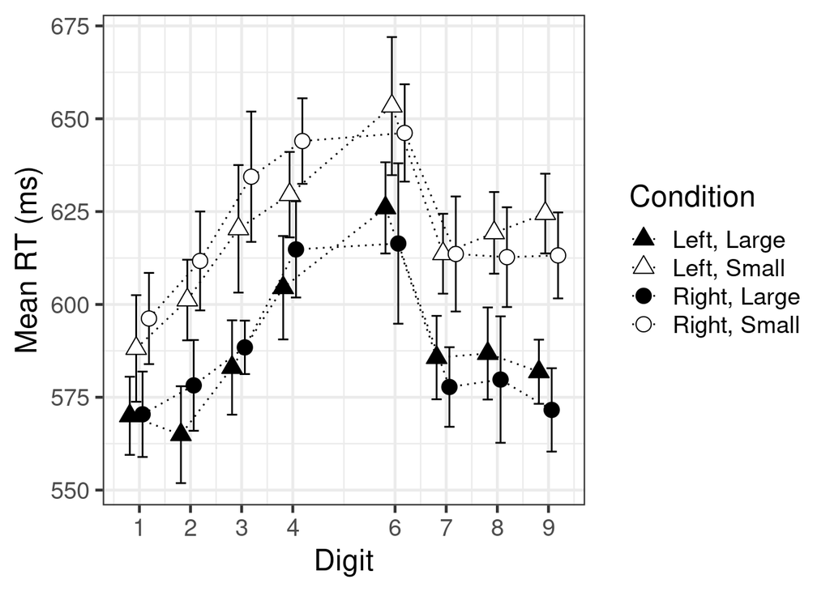